# Coronavirus report - Sweden

Mahima Jayasingha

2022-10-06

# 1.0 Introduction

## 1.1 Visualization of the Location

#### Sweden, country located on the Scandinavian Peninsula in northern Europe.Sweden occupies the greater part of the Scandinavian Peninsula, which it shares with Norway.Sweden lies to the southwest of Finland. A long coastline forms the country’s eastern border, extending along the Gulf of Bothnia and the Baltic Sea; a narrow strait, known as The Sound (Öresund), separates Sweden from Denmark in the south. A shorter coastline along the Skagerrak and Kattegat straits forms Sweden’s border to the southwest, and Norway lies to the west. Sweden extends some 1,000 miles (1,600 km) to the north and south and 310 miles (500 km) to the east and west.The country is traditionally divided into three regions: to the north is Norrland, the vast mountain and forest region; in central Sweden is Svealand,an expanse of lowland in the east and highland in the west; and in the south is Götaland, which includes the Småland highlands and, at the southern extremity,the small but rich plains of Skåne. In the far north the region of Lappland overlaps Norrland and northern Finland.

[interactive chart not shown]

## 1.2 Climate of Sweden

#### Winter and summer temperature differences in Sweden are extreme, but generally the country enjoys a temperate climate, thanks to the Gulf Stream.Sweden’s proximity to the North Atlantic and prevailing south-westerly to westerly winds result in a climate that is mild in the winter months, but the northernmost part of the country has a sub-Arctic climate with long, cold and snowy winters. In the period 1961-90 the mean temperature in January was 0°C in southernmost Sweden, while the coldest northern valleys had 17°C.The maximum daily mean July temperature was approximately +17°C in south-eastern Sweden and just over 10°C in the north. Passing low-pressure systems bring precipitation that is fairly copious all year round, but heaviest in the summer and autumn. Annual precipitation is some 1,000 mm. Since most low-pressure systems move in across the country from the west or south-west,the western parts of Sweden receive the most precipitation.

## 1.3 Coronavirus disease in Sweden

#### Sweden has faced severe issues as a result of the COVID-19 pandemic.The pandemic has affected many aspects of daily life in Sweden and has led to a dramatic loss of human life, especially among older and poorer residents. It has also caused unprecedented disruption to family life, work, schooling, the care continuum and society, and no one has escaped its impact.

### Actions taken by the goverment,

#### Swedish authorities initially followed a disease control path that differed from many other countries, extensive restrictions were implemented at a later date.In late June 2020, the Swedish Government established a national COVID-19 Commission to examine how Sweden handled the pandemic. Interim reports were published in 2020 and 2021,and the final report was published on 25 February 2022. By the time all three reports had been published, 15 800 people in Sweden had died after being diagnosed with COVID-19,which was 1.5 per 1000 inhabitants,4 according to the National Board for Health and Welfare (NBHW). The Commission stated in its report that it preferred the organisation’ ’s definition of COVID-19 deaths to the definition of the Swedish Public Health Agency (PHA). The NBHW only included deaths if a physician had indicated that COVID-19 was the underlying cause of death The PHA, which also included deaths ≤30 days after someone had tested positive for COVID-19, had reported 17 497 deaths during the same period. This was 1.7 per 1000 inhabitants. Swedish Covid-19 vaccinations started in December 2020. At the end of March 2022, 87 per cent of the population aged 12 or older had been vaccinated with at least two doses.Of the population aged 18 or older, 62 per cent had been vaccinated with three doses.

# 2.0 Exploratory Data Analysis.

## 2.1 Confirmed cases in the Sweden

Table 01: summary for COVID-19 confirmed cases in Sweden

|  | date | country | type | cases |
| --- | --- | --- | --- | --- |
|  | Min. :2020-01-22 | Length:884 | Length:884 | Min. : 0.0 |
|  | 1st Qu.:2020-08-29 | Class :character | Class :character | 1st Qu.: 0.0 |
|  | Median :2021-04-07 | Mode :character | Mode :character | Median : 259.5 |
|  | Mean :2021-04-07 | NA | NA | Mean : 2845.9 |
|  | 3rd Qu.:2021-11-14 | NA | NA | 3rd Qu.: 1479.0 |
|  | Max. :2022-06-23 | NA | NA | Max. :138985.0 |

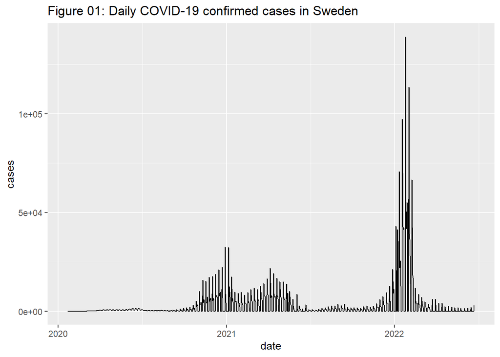

## 2.2 Recovered cases in the Sweden

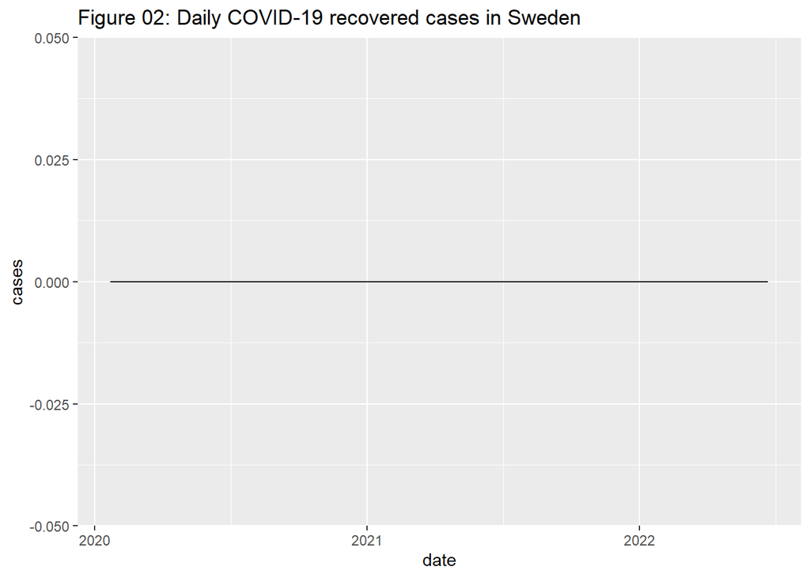

## 2.3 Death cases in the Sweden

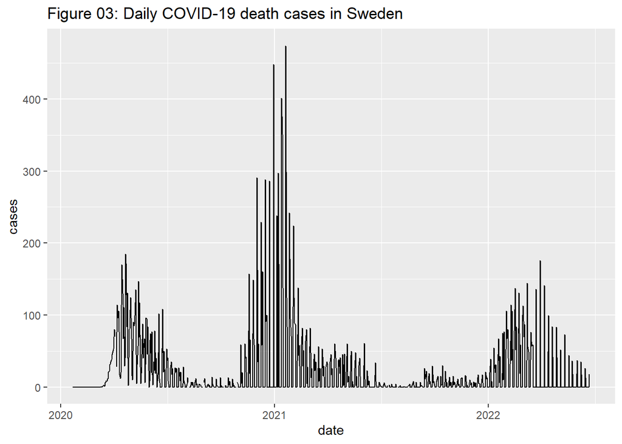

## 2.4 Summary cases in the Sweden

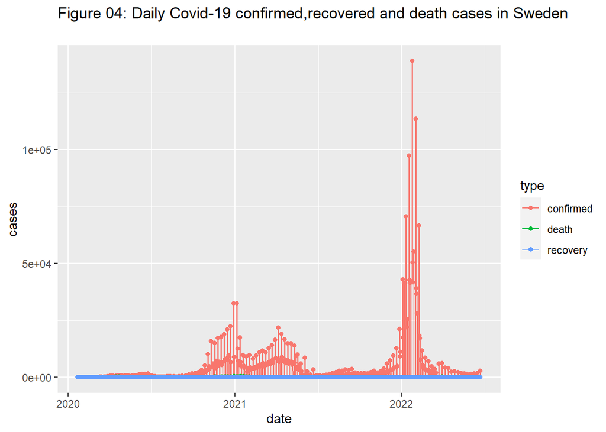

Table 02: mean of COVID-19 cases for each type

| type | Mean |
| --- | --- |
| Confirmed | 2845.89253 |
| Recovered | 0.00000 |
| Death | 21.59842 |

## 2.5 Comparision of COVID-19 in Sweden with Denmark

### Confiremed cases comparison:

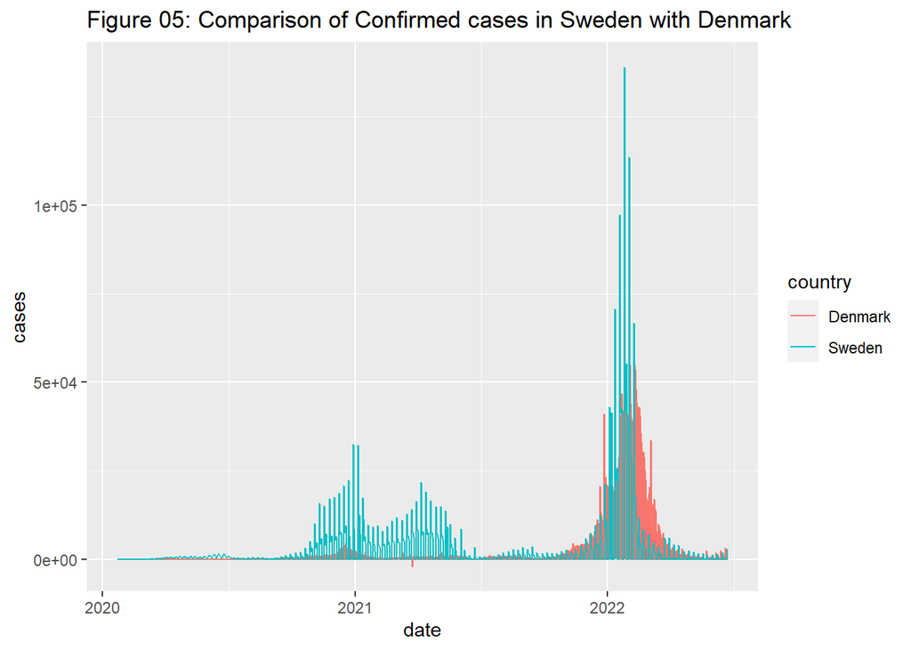

### Recovered cases comparison:

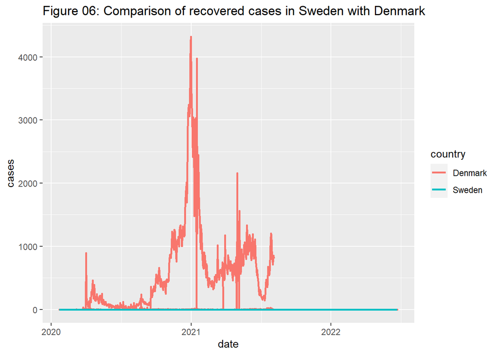